# Document Classification

**Aim:** This notebook compares the performance of the Naive Bayes classifier to a neural net for document classification after feature transformation.  
Final results show significant increase in performance metrics when using a shallow neural net compared to a Naive Bayes classifier.

**Data:** The data is obtained from the **training set** of the Kaggle competition, [Coleridge Initiative - Show Us the Data](https://www.kaggle.com/c/coleridgeinitiative-show-us-the-data) and consists of published research articles (documents) and their labels, which are datasets cited by the articles. Since the public test set is limited to only 4 documents, the focus will be on the training set, containing 19,661 records.

The aim of the competition was to create a model capable of identifying datasets cited in research papers. The inherent difficulty of this task has to do with the infinitely large number of datasets in the wild that any given article can cite, while having a limited number of datasets (labels) for training a model.

Unlike the competition, the purpose here is to simply create a classifier on existing dataset labels and accurately classify new documents that contain one of such labels. Hence, we will evaluate the performance of a baseline classifier (Naive Bayes) to a neural net by spliting the train dataset from the competition to train, validation and test sets of our own.

This notebook is structured as follows:

1. Data preprocessing and exploratory data analysis
2. Feature transformation using TFIDF and label encoding
3. Evaluating of Naive Bayes classifier
4. Evaluation of neural net classifier
5. Conclusion

**Import the required libraries:**

```python
import os
import json
import re
import pandas as pd
import numpy as np
from sklearn.model_selection import train_test_split
from sklearn.feature_extraction.text import TfidfVectorizer
from sklearn.preprocessing import LabelEncoder
from sklearn.metrics import accuracy_score, confusion_matrix, matthews_corrcoef, f1_score
from sklearn.naive_bayes import MultinomialNB
import tensorflow as tf
from keras.models import Sequential
from keras.layers import Dense
from keras.callbacks import ModelCheckpoint, EarlyStopping
from keras.utils import np_utils
import matplotlib.pyplot as plt
from scipy import stats
from wordcloud import WordCloud
from random import randint
```

**Initialize the LabelEncoder and TFIDFVectorizer methods:**

```python
le = LabelEncoder()
vectorizer = TfidfVectorizer(input='content')
```

**Below are some functions that will help parse the data and evaluate our model:**

```python
def json_to_text(filename, directory_path):
    """convert json file into concatenated text data."""
    content = list()
    file_path = os.path.join(directory_path, filename + '.json')
    with open(file_path, 'r') as f:
        json_file = json.load(f)
        for data in json_file:
            content.append(data.get('text'))
    return ''.join(content)

def process_text(text):
    """convert text to alphanumeric lowercase characters."""
    text = re.sub('[^A-Za-z0-9]+', ' ', str(text).lower()).strip()
    return text

def convert_sparse_matrix_to_sparse_tensor(x):
    """convert scikit-learn sparse matrix into TensorFlow tensors."""
    coo = x.tocoo()
    indices = np.mat([coo.row, coo.col]).transpose()
    return tf.sparse.reorder(tf.SparseTensor(indices, coo.data, coo.shape))

def jaccard_coef(str1, str2):
    """return the Jaccard similarity coefficient of two strings.
    Algorithm provided by competition."""
    a = set(str1.lower().split())
    b = set(str2.lower().split())
    c = a.intersection(b)
    return float(len(c)) / (len(a) + len(b) - len(c))
```

## Data Preprocessing and Exploratory Analysis

**Read the data:**

```python
df = pd.read_csv('../input/coleridgeinitiative-show-us-the-data/train.csv')
train_directory = '../input/coleridgeinitiative-show-us-the-data/train'
```

Let's look at the first and last 5 entries of the dataframe and go over each column. Here is a description of each of the columns from the competiton:

- id - publication id - note that there are multiple rows for some training documents, indicating multiple mentioned datasets
- pub_title - title of the publication (a small number of publications have the same title)
- dataset_title - the title of the dataset that is mentioned within the publication
- dataset_label - a portion of the text that indicates the dataset
- cleaned_label - the dataset_label, as passed through the clean_text function from the Evaluation page

```python
df.head()
```

|  | Id | pub_title | dataset_title | dataset_label | cleaned_label |
| --- | --- | --- | --- | --- | --- |
| 0 | d0fa7568-7d8e-4db9-870f-f9c6f668c17b | The Impact of Dual Enrollment on College Degre... | National Education Longitudinal Study | National Education Longitudinal Study | national education longitudinal study |
| 1 | 2f26f645-3dec-485d-b68d-f013c9e05e60 | Educational Attainment of High School Dropouts... | National Education Longitudinal Study | National Education Longitudinal Study | national education longitudinal study |
| 2 | c5d5cd2c-59de-4f29-bbb1-6a88c7b52f29 | Differences in Outcomes for Female and Male St... | National Education Longitudinal Study | National Education Longitudinal Study | national education longitudinal study |
| 3 | 5c9a3bc9-41ba-4574-ad71-e25c1442c8af | Stepping Stone and Option Value in a Model of ... | National Education Longitudinal Study | National Education Longitudinal Study | national education longitudinal study |
| 4 | c754dec7-c5a3-4337-9892-c02158475064 | Parental Effort, School Resources, and Student... | National Education Longitudinal Study | National Education Longitudinal Study | national education longitudinal study |

```python
df.tail()
```

|  | Id | pub_title | dataset_title | dataset_label | cleaned_label |
| --- | --- | --- | --- | --- | --- |
| 19656 | b3498176-8832-4033-aea6-b5ea85ea04c4 | RSNA International Trends: A Global Perspectiv... | RSNA International COVID-19 Open Radiology Dat... | RSNA International COVID Open Radiology Database | rsna international covid open radiology database |
| 19657 | f77eb51f-c3ac-420b-9586-cb187849c321 | MCCS: a novel recognition pattern-based method... | CAS COVID-19 antiviral candidate compounds dat... | CAS COVID-19 antiviral candidate compounds dat... | cas covid 19 antiviral candidate compounds dat... |
| 19658 | ab59bcdd-7b7c-4107-93f5-0ccaf749236c | Quantitative Structure–Activity Relationship M... | CAS COVID-19 antiviral candidate compounds dat... | CAS COVID-19 antiviral candidate compounds dat... | cas covid 19 antiviral candidate compounds dat... |
| 19659 | fd23e7e0-a5d2-4f98-992d-9209c85153bb | A ligand-based computational drug repurposing ... | CAS COVID-19 antiviral candidate compounds dat... | CAS COVID-19 antiviral candidate compounds dat... | cas covid 19 antiviral candidate compounds dat... |
| 19660 | fd23e7e0-a5d2-4f98-992d-9209c85153bb | A ligand-based computational drug repurposing ... | CAS COVID-19 antiviral candidate compounds dat... | CAS COVID-19 antiviral candidate compounds data | cas covid 19 antiviral candidate compounds data |

**Prepare Train Data:**  
Let’s add another column to the dataframe to include the text of each document, without titles or headings using the *json_to_text()* function. We can then use the *process_text()* function to turn the content of each document to lowercase alphanumeric characters. Below we can see the difference in the content of the first document before and after using the *process_text()* method.

```python
df['text'] = df['Id'].apply(json_to_text, directory_path=train_directory)
print("Example of text before cleaning:")
print()
df['text'][0][0:500]
```

```
Example of text before cleaning:
```

```
'This study used data from the National Education Longitudinal Study (NELS:88) to examine the effects of dual enrollment programs for high school students on college degree attainment. The study also reported whether the impacts of dual enrollment programs were different for first generation college…
```

```python
print("Example of text after cleaning:")
print()
df['text'] = df['text'].apply(process_text)
df['text'][0][0:500]
```

```
Example of text after cleaning:
```

```
'this study used data from the national education longitudinal study nels 88 to examine the effects of dual enrollment programs for high school students on college degree attainment the study also reported whether the impacts of dual enrollment programs were different for first generation college st…
```

**WordCloud**:  
To get a visual feel of the labels in the *dataset_title* and *dataset_label*, lets create wordcloud plots for each.

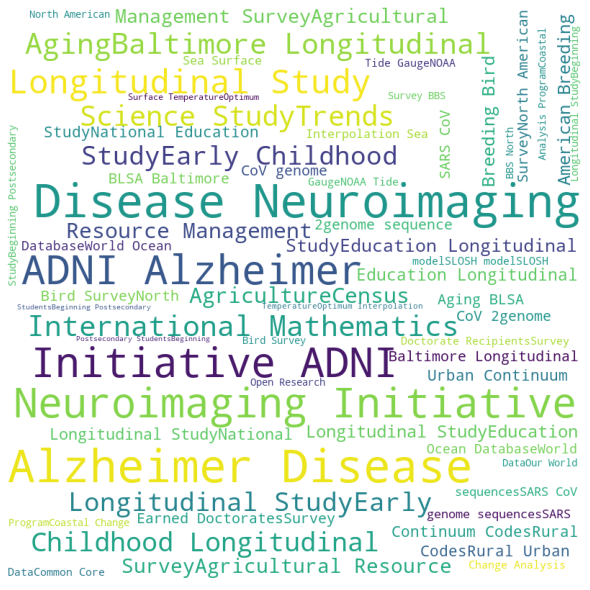

```python
wordcloud = WordCloud(width = 800, height = 800,
                background_color ='white',
                min_font_size = 10).generate("".join(df['dataset_label']))

# plot the WordCloud image
plt.figure(figsize = (8, 8), facecolor = None)
plt.imshow(wordcloud)
plt.axis("off")
plt.tight_layout(pad = 0)

plt.show()
```

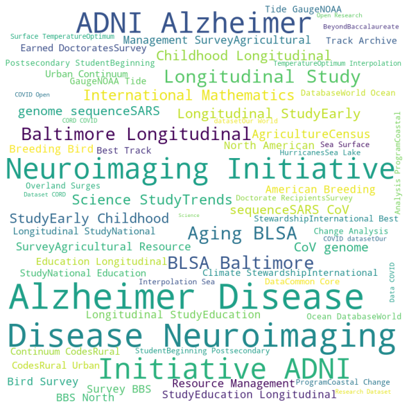

```python
wordcloud = WordCloud(width = 800, height = 800,
                background_color ='white',
                min_font_size = 10).generate("".join(df['dataset_title']))

# plot the WordCloud image
plt.figure(figsize = (8, 8), facecolor = None)
plt.imshow(wordcloud)
plt.axis("off")
plt.tight_layout(pad = 0)

plt.show()
```

**Class balance and distribution of labels:**  
Let’s examine the number of unique values in each of the *dataset_title*, *dataset_label*, and *cleaned_label* columns. As can be seen below, there are 45, 130, and 130 unique values in *dataset_title*, *dataset_label*, and *cleaned_label* columns, respectively.

```python
[(f'{col}: {len(df[col].unique())}') for col in df.columns[2:-1]]
```

```
['dataset_title: 45', 'dataset_label: 130', 'cleaned_label: 130']
```

Next, let’s examine the distribution of labels across each one of these label columns. As can be seen below, the *dataset_title* column has the least variance and is the least imbalance when compared to the *dataset_label* and *cleaned_label* columns. We can compare variance of samples with different means using the **coefficient of variation** measure.

```python
print(f'Unique value counts of dataset_title: \n{list(df.dataset_title.value_counts())}')
print(f'coefficient of variation: {np.round(stats.variation(list(df.dataset_title.value_counts())),4)}')
print(f'\nUnique value counts of dataset_label: \n{list(df.dataset_label.value_counts())}')
print(f'coefficient of variation: {np.round(stats.variation(list(df.dataset_label.value_counts())),4)}')
print(f'\nUnique value counts of cleaned_label: \n{list(df.cleaned_label.value_counts())}')
print(f'coefficient of variation: {np.round(stats.variation(list(df.cleaned_label.value_counts())),4)}')
```

```
Unique value counts of dataset_title:
[6144, 1589, 1163, 1011, 860, 743, 676, 660, 585, 550, 509, 490, 461, 441, 386, 368, 326, 326, 312, 309, 306, 288, 223, 185, 132, 104, 92, 85, 65, 44, 38, 34, 30, 29, 28, 22, 13, 10, 6, 4, 4, 3, 3, 2, 2]
coefficient of variation: 2.1253

Unique value counts of dataset_label:
[3673, 2400, 1163, 1156, 1011, 676, 643, 623, 550, 490, 433, 428, 380, 314, 304, 299, 298, 280, 255, 252, 244, 241, 222, 212, 199, 198, 190, 158, 150, 134, 132, 114, 107, 105, 92, 88, 87, 86, 71, 70, 70, 65, 65, 64, 62, 61, 58, 55, 44, 38, 35, 30, 28, 26, 25, 24, 21, 19, 17, 15, 14, 14, 13, 13, 12, …
coefficient of variation: 2.8059

Unique value counts of cleaned_label:
[3673, 2400, 1163, 1156, 1011, 676, 643, 623, 550, 490, 433, 428, 380, 314, 304, 299, 298, 280, 255, 252, 244, 241, 222, 212, 199, 198, 190, 158, 150, 134, 132, 114, 107, 105, 92, 88, 87, 86, 71, 70, 70, 65, 65, 64, 62, 61, 58, 55, 44, 38, 35, 30, 28, 26, 25, 24, 21, 19, 17, 15, 14, 14, 13, 13, 12, …
coefficient of variation: 2.8059
```

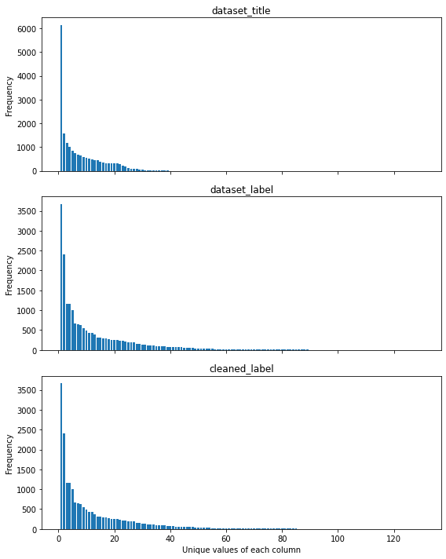

```python
fig, axs = plt.subplots(3, figsize=(8,10), sharex=True)
axs[0].bar(range(1,46), df.dataset_title.value_counts())
axs[0].set_title('dataset_title')
axs[1].bar(range(1,131), df.dataset_label.value_counts())
axs[1].set_title('dataset_label')
axs[2].bar(range(1,131), df.cleaned_label.value_counts())
axs[2].set_title('cleaned_label')


for ax in axs.flat:
    ax.set(xlabel='Unique values of each column', ylabel='Frequency')

for ax in axs.flat:
    ax.label_outer()

fig.tight_layout()
plt.show()
```

**Encode Labels**  
We will choose the *dataset_title* with the least imbalance as our label column and convert each label in the column to an integer using the *LabelEncoder()* method. Let’s look at 3 random labels before and after integer encoding.

```python
print("Labels of items 0, 1000, and 5000 before encoding:")
print()
print(df.dataset_title[0], '--', df.dataset_title[1000], '--', df.dataset_title[5000])

df['dataset_title'] = le.fit_transform(df['dataset_title'])
print()
print("Labels of items 0, 1000, and 5000 after encoding:")
print()
print(df.dataset_title[0], '--', df.dataset_title[1000], '--', df.dataset_title[5000])
```

```
Labels of items 0, 1000, and 5000 before encoding:

National Education Longitudinal Study -- NOAA Tide Gauge -- Alzheimer's Disease Neuroimaging Initiative (ADNI)

Labels of items 0, 1000, and 5000 after encoding:

25 -- 23 -- 3
```

## Naive Bayes classifier

**Split data into train and test sets for classification by Naive Bayes classifier:**

```python
x_train, x_test, y_train, y_test = train_test_split(df['text'], df['dataset_title'],
                                                    test_size=0.33, random_state=42)
```

**Encode our features using TFIDF**:  
Just as we have encoded the label for our data, we need to convert our features represented by strings in each document to a numerical form to be able to utilize machine learning models. One way to do this is through term-frequency inverse document-frequency [(TFIDF)](https://en.wikipedia.org/wiki/Tf%E2%80%93idf).  
TFIDF is an improvement over the bag-of-words method, where in addition to counting the frequencies of words in each document, we obtain a better sense of how important a word is over the entire corpus of documents by multiplying the frequency with a weighting scheme called inverse document frequency. This will result in a sparse matrix, where most values are zero. Each column will represent a word with rows containing the TFIDF score in each document for that word. Thankfully, these TFIDF matrices can be stored in memory optimally using one of Python’s scientific libraries such as *SciPy*.

```python
# fit the tfidf vectorizer on train data and transform it
x_train = vectorizer.fit_transform(x_train)
# use the same vectorizer to transform the test set
x_test = vectorizer.transform(x_test)
```

```python
print(f'Length of entire data: {len(df)}')
print(f'Length of x_train and y_train: {x_train.shape[0], y_train.shape[0]}')
print(f'Length of x_test and y_test: {x_test.shape[0], y_test.shape[0]}')
print(f'Length of train+test data: {x_train.shape[0] + x_test.shape[0]}')
```

```
Length of entire data: 19661
Length of x_train and y_train: (13172, 13172)
Length of x_test and y_test: (6489, 6489)
Length of train+test data: 19661
```

```python
multino_naiveB_clf = MultinomialNB()
multino_naiveB_clf.fit(x_train, y_train)
y_pred = multino_naiveB_clf.predict(x_test)
print(f'Accuracy of the Naive Bayes Classifier: {accuracy_score(y_test, y_pred)}')
print(f'Matthews correlation coefficient of the Naive Bayes Classifier: {matthews_corrcoef(y_test, y_pred)}')
```

```
Accuracy of the Naive Bayes Classifier: 0.3145322854060718
Matthews correlation coefficient of the Naive Bayes Classifier: 0.044503354148285344
```

## Neural Net Classifier

**Split data into train and test sets for classification by a shallow neural net:**

```python
# delete previous split from memory
del x_train, x_test, y_train, y_test

x_train, x_test, y_train, y_test = train_test_split(df['text'], df['dataset_title'], test_size=0.33,
                                                random_state=42)
x_train, x_val, y_train, y_val = train_test_split(x_train, y_train, test_size=0.33, random_state=42)
```

```python
# fit the tfidf vectorizer on train data and transform it
x_train = vectorizer.fit_transform(x_train)
# use the same vectorizer to transform the validation and test sets
x_val = vectorizer.transform(x_val)
x_test = vectorizer.transform(x_test)
```

```python
print(f'Length of entire data: {len(df)}')
print(f'Length of x_train and y_train: {x_train.shape[0], y_train.shape[0]}')
print(f'Length of val data: {x_val.shape[0], y_val.shape[0]}')
print(f'Length of x_test and y_test: {x_test.shape[0], y_test.shape[0]}')
print(f'Length of train+test+val data: {x_train.shape[0] + x_val.shape[0] + x_test.shape[0]}')
```

```
Length of entire data: 19661
Length of x_train and y_train: (8825, 8825)
Length of val data: (4347, 4347)
Length of x_test and y_test: (6489, 6489)
Length of train+test+val data: 19661
```

**Convert integer encoded label into one-hot encoding:**

```python
encoded_y_train = np_utils.to_categorical(y_train)
encoded_y_val = np_utils.to_categorical(y_val)
encoded_y_test = np_utils.to_categorical(y_test)
```

**Convert tfidf matrixes into tensorflow tensors:**

```python
x_train_tf = convert_sparse_matrix_to_sparse_tensor(x_train)
x_val_tf = convert_sparse_matrix_to_sparse_tensor(x_val)
```

**Create the layers of the neural net:**

```python
best_model_file_name = 'nlp_model.h5'
input_dim = x_test.shape[1]
output_dim = len(np.unique(y_train)) + 1
model = Sequential()
model.add(Dense(100, input_dim=input_dim, activation='relu'))
model.add(Dense(50, activation='relu'))
model.add(Dense(output_dim, activation='softmax'))
model.compile(loss='categorical_crossentropy', optimizer='adam', metrics=['accuracy'])
mdl_es = EarlyStopping(monitor='val_loss', patience=50, verbose=1, mode='min')
mdl_mc = ModelCheckpoint(best_model_file_name, save_best_only=True, monitor='val_loss', mode='min', verbose=1)
```

**Fit the model**

```python
model.fit(x_train_tf, encoded_y_train, epochs=10, validation_data=(x_val_tf, encoded_y_val), verbose=1,
          callbacks=[mdl_es, mdl_mc])
```

[output not shown]

```python
history = model.fit(x_train_tf, encoded_y_train, epochs=10, validation_data=(x_val_tf, encoded_y_val), verbose=1,
          callbacks=[mdl_es, mdl_mc])
```

```
Epoch 00001: val_loss improved from inf to 0.89773, saving model to nlp_model.h5

Epoch 00002: val_loss improved from 0.89773 to 0.64679, saving model to nlp_model.h5

Epoch 00003: val_loss improved from 0.64679 to 0.58467, saving model to nlp_model.h5

Epoch 00004: val_loss did not improve from 0.58467

Epoch 00005: val_loss did not improve from 0.58467

Epoch 00006: val_loss did not improve from 0.58467

Epoch 00007: val_loss did not improve from 0.58467

Epoch 00008: val_loss did not improve from 0.58467

Epoch 00009: val_loss did not improve from 0.58467

Epoch 00010: val_loss did not improve from 0.58467
```

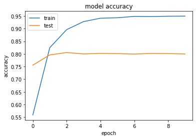

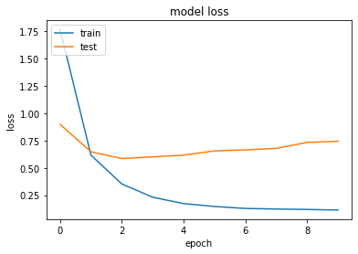

```python
# summarize history for accuracy
plt.plot(history.history['accuracy'])
plt.plot(history.history['val_accuracy'])
plt.title('model accuracy')
plt.ylabel('accuracy')
plt.xlabel('epoch')
plt.legend(['train', 'test'], loc='upper left')
plt.show()
# summarize history for loss
plt.plot(history.history['loss'])
plt.plot(history.history['val_loss'])
plt.title('model loss')
plt.ylabel('loss')
plt.xlabel('epoch')
plt.legend(['train', 'test'], loc='upper left')
plt.show()
```

**Evaluate model:**

```python
x_test_tf = convert_sparse_matrix_to_sparse_tensor(x_test)
y_predict = model.predict(x_test_tf)
perf = model.evaluate(x_test_tf, encoded_y_test)
print(perf)
```

```
[0.7217847108840942, 0.8013561367988586]
```

```python
y_predict_encoded = [i.argmax() for i in y_predict]
```

```python
print(f'Accuracy of the neural net classifier: {perf[1]}')
print(f'Matthews correlation coefficient of {matthews_corrcoef(y_test, y_predict_encoded)}')
```

```
Accuracy of the neural net classifier: 0.8013561367988586
Matthews correlation coefficient of 0.773272262338084
```

```python
print("ground truth:")
print(le.inverse_transform(y_test[10:15]))
print("predicted values:")
print(le.inverse_transform(y_predict_encoded[10:15]))
```

```
ground truth:
["Alzheimer's Disease Neuroimaging Initiative (ADNI)"
 "Alzheimer's Disease Neuroimaging Initiative (ADNI)"
 'Beginning Postsecondary Student'
 "Alzheimer's Disease Neuroimaging Initiative (ADNI)"
 'Common Core of Data']
predicted values:
["Alzheimer's Disease Neuroimaging Initiative (ADNI)"
 "Alzheimer's Disease Neuroimaging Initiative (ADNI)"
 'Baccalaureate and Beyond'
 "Alzheimer's Disease Neuroimaging Initiative (ADNI)"
 'Common Core of Data']
```

## Conclusion

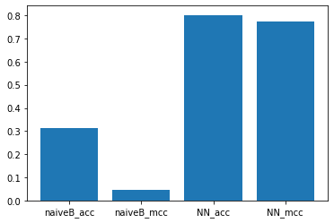

```python
y = [ 0.3145, 0.0445, 0.8014, 0.7733]
x = ['naiveB_acc', 'naiveB_mcc', 'NN_acc', 'NN_mcc']
plt.bar(x,y)
plt.show()
```